# Clustering of HPLC samples

# Exploration and clustering of the Boussole HPLC dataset

This work aims to explore the raw pigment data of the year of concomittant HPLC and 3X1M sampling at the Boussole site.  
The ultimate goal is to evaluate the possibility of using the 3X1M fluorometer to get informations on the phytoplankton community composition.  
To do so, we will try to create a classification model that will allow to predict the type of phytoplankton community.  
The “type of phytoplankton community” must be defined in this notebook. We want to evaluate the major successions in pigment composition and the co-appearance of pigments to create a couple of cluster that occurs at given depth and time in the year.  
***  
At first, we load the HPLC data, that have been already match with 3X1M data.

```r
library(tidyverse)

local_path <- here::here() #define the local path
data_path <- paste(local_path, "Boussole/Output/Data/Compiled/echo_hplc_bouss.csv", sep ="/")

hplc <- read_csv(data_path)

#define some pigment vec to ease the data manipulation later
pigments <- c("chl_c1_c2", "chl_c3", "peri", "but", "fuco", "neox", "prasi", "viola", "hex", "diad", "allo", "diat", "zea", "lutein", "dv_chlb", "chlb", "t_chlb", "dv_chla", "chla", "t_chla")
pigtosum <- c("chl_c1_c2", "chl_c3", "peri", "but", "fuco", "neox", "prasi", "viola", "hex", "diad", "allo", "diat", "zea", "lutein", "t_chlb")
pigment_to_plot <- pigments[!pigments %in% c("t_chla", "t_chlb", "chla")]
data_to_plot <- select(hplc, bouss, date, depth, sumpig, pigments) %>%
  mutate_at(all_of(pigment_to_plot), ~./sumpig) %>%
  pivot_longer(all_of(pigment_to_plot), values_to = "proportion", names_to = "pigment")
```

We will visualize each sample as a dot, the size of the dot is the Chla concentration and the colour correspond to the fraction of the pigment in the total accessories pigment concentration.

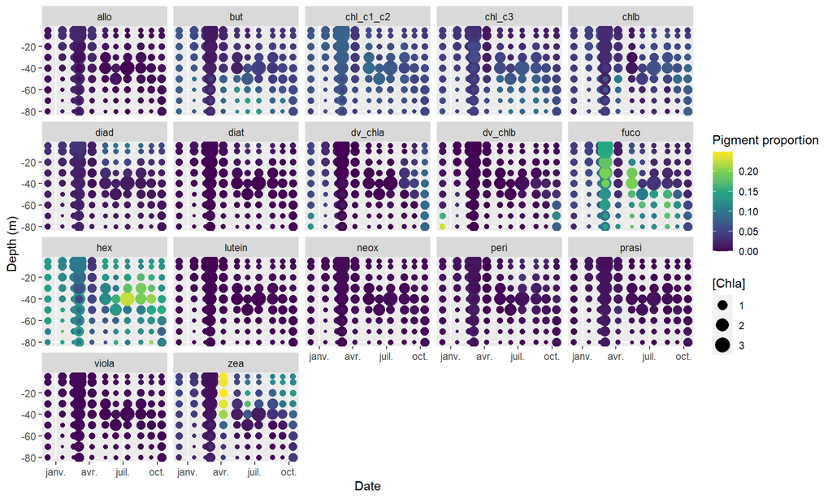

Figure: Proportion of each pigment in the total pigment concentration for each HPLC sample at BOUSSOLE

```r
g <- ggplot(data_to_plot)+
  geom_point(aes(x = date, y = -depth, colour = proportion, size = t_chla))+
  scale_colour_viridis_c(name = "Pigment proportion")+
  xlab("Date")+
  ylab("Depth (m)")+
  scale_size(name = "[Chla]")+
  facet_wrap(.~pigment)
g
```

We observe some interesting features here. First, the Chla concentration start to increase in March/April and deepen during the following month. This is coherent with what has been previously described. We can notice the early increase of the [Chla] and the magnitude of it, we reach 3 mg.m-3 !!  
This increase of Chla is associated with an increase of the fucoxanthin proportion indicating of a bloom of Diatom. After which, the diatoms are mainly present in the deep layer (< 50m). The 19’-HF pigment represent more that 10% of the pigment community in almost every samples. we also notice an outbreak of Zeaxanthin in the surface/subsurface layer in april, after which the zeaxanthin represent a significant part of the pigment composition at the surface. Finally, we can observe a depth community with a significant concentration of 19’-bf and Chlb/Chlc.  
We will now reduce the number of dimension (i.e. the number of descriptors) by performing a CA, that consist of regrouping samples with similar relativ abundances (here concentration). This will allow us to perform hierarchical clustering.

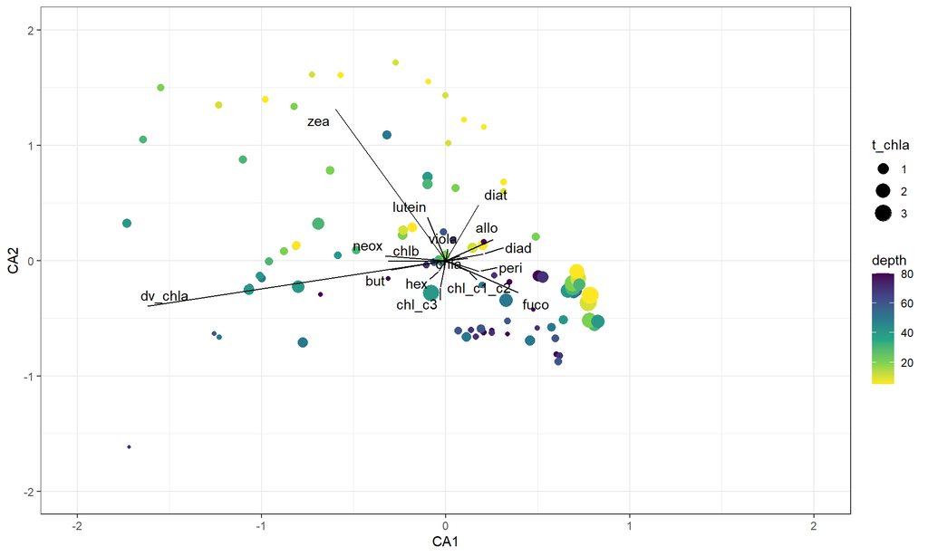

Figure: CA rpojection of HPLC data

```r
library(vegan)

pigments_afc <- pigments[pigments != "t_chla" & pigments != "t_chlb"]

AFC <- cca(select(hplc, all_of(pigments_afc)))

scores <- data.frame(scores(AFC, choices = c(1,2,3), display = "site"))
data_ca <- bind_cols(hplc, scores)

pigscore <- data.frame(scores(AFC, choices = c(1,2,3), display = "species"))

ggplot(data_ca)+
  geom_point(aes(x = CA1, y = CA2, colour = depth, size = t_chla))+
  geom_segment(aes(x = 0, xend = CA1, y = 0, yend = CA2), data = pigscore)+
  ggrepel::geom_text_repel(aes(x = CA1, y = CA2, label = rownames(pigscore)), data = pigscore)+
  scale_color_viridis_c(direction = -1)+
  xlim(-2,2)+
  ylim(-2,2)+
  theme_bw()
```

This analysis already separate samples of different depth, chla concentration… Let’s see what clustering can give us.

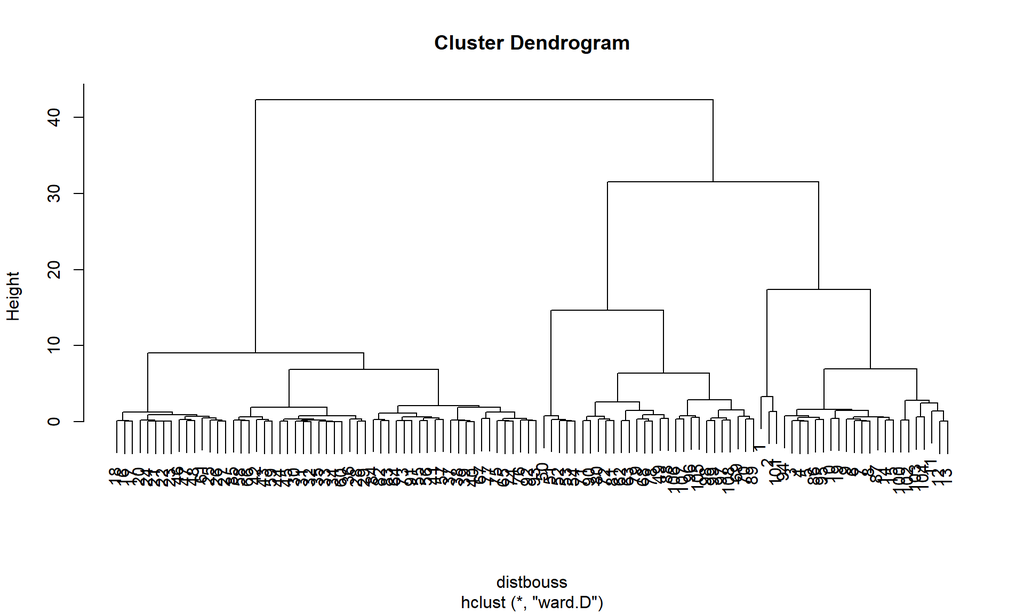

Figure: Clustering tree

```r
data_ca <- data_ca %>% mutate("f532_f440" = fluo_532 /fluo_440)
distbouss <- dist(select(data_ca, f440_f470, f532_f470, CA1, CA2))

plot(hclust(distbouss, method = "ward.D"))
```

```r
data_ca$group <- as.factor(cutree(hclust(distbouss, method = "ward.D"),  h = 20))
```

Following this tree I propose to cut at h = 20.

```r
data_to_plot <- select(data_ca, bouss, date, depth, sumpig, pigments, group) %>%
  mutate_at(all_of(pigment_to_plot), ~./sumpig) %>%
  pivot_longer(all_of(pigment_to_plot), values_to = "proportion", names_to = "pigment")
```

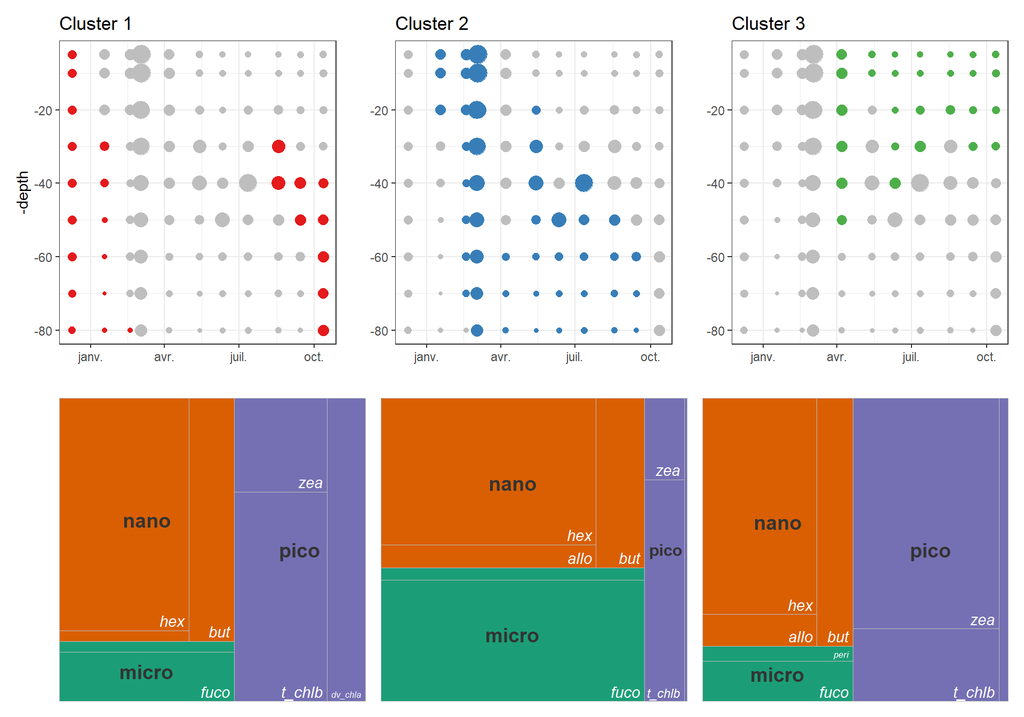

Figure: cluster composition

```r
# cluster visualization ---------------------------------------------------
library(treemap)
library(treemapify)
library(patchwork)

cluster_viz <- data_ca %>% select(pigment_to_plot, group) %>%  group_by(group) %>%
  summarise_all(mean, na.rm = "TRUE") %>% ungroup() %>%
  pivot_longer(all_of(pigment_to_plot), values_to = "concentration", names_to = "pigment")

tplot <- data_ca %>%
  group_by(group) %>%
  mutate(wdp = 1.56 * fuco + 0.92 * peri + 4.8 * allo + 1.02 * but + 1.12 * hex + 1.51 * zea + 0.69 * t_chlb,
         micro = (1.56 * fuco + 0.92 * peri)/wdp,
         nano = (4.8 * allo + 1.02 * but + 1.51 * hex)/wdp,
         pico = (1.51 * zea + 0.69 * t_chlb)/wdp) %>%
  summarise_at(vars(c(pico, nano, micro, t_chlb, fuco, zea, peri, allo, hex, but, dv_chla)), mean, na.rm = TRUE) %>%
  ungroup() %>%
  pivot_longer(t_chlb:dv_chla, names_to = 'pigment', values_to = 'concentration') %>%
  mutate(size = ifelse(pigment %in% c('zea', 't_chlb', 'dv_chla'), 'pico', ifelse(pigment %in% c('allo', 'hex', 'but'), 'nano', ifelse(pigment %in% c('fuco', 'peri'), 'micro', 'error'))))

tplot1 <- filter(tplot, group == '1')
tplot2 <- filter(tplot, group == '2')
tplot3 <- filter(tplot, group == '3')
#tplot4 <- filter(tplot, group == '4')



ga <- ggplot(data_to_plot)+
  geom_point(aes(x = date, y = -depth, size = t_chla), colour = "Grey")+
  geom_point(data = filter(data_to_plot, group == "1"), aes(x =date, y = -depth, size = t_chla), colour = "#e41a1c")+
  scale_size(guide = "none")+
  xlab("")+
  theme_bw()+
  ggtitle("Cluster 1")

gb <- ggplot(data_to_plot)+
  geom_point(aes(x = date, y = -depth, size = t_chla), colour = "Grey")+
  geom_point(data = filter(data_to_plot, group == "2"), aes(x =date, y = -depth, size = t_chla), colour = "#377eb8")+
  xlab("")+
  ylab("")+
  theme_bw()+
  scale_size(guide = "none")+
  ggtitle("Cluster 2")

gc <- ggplot(data_to_plot)+
  geom_point(aes(x = date, y = -depth, size = t_chla), colour = "Grey")+
  geom_point(data = filter(data_to_plot, group == "3"), aes(x =date, y = -depth, size = t_chla), colour = "#4daf4a")+
  scale_size(guide = "none")+
  theme_bw()+
  xlab("")+
  ylab("")+
  ggtitle("Cluster 3")

#gd <- ggplot(data_to_plot)+
  # geom_point(aes(x = date, y = -depth, size = t_chla), colour = "Grey")+
  # geom_point(data = filter(data_to_plot, group == "4"), aes(x =date, y = -depth, size = t_chla), colour = "#984ea3")+
  # scale_size(guide = "none")+
  # theme_bw()+
  # xlab("")+
  # ylab("")+
  # ggtitle("Cluster 4")
#create the three treeplot

g2 <- ggplot(tplot1, aes(area = concentration, fill = size, subgroup = size, label = pigment))+
  geom_treemap(layout = 'fixed')+
  geom_treemap_subgroup_text(layout = 'fixed', place = 'middle', fontface = 'bold', size = 14)+
  geom_treemap_text(layout = 'fixed', place = 'bottomright', 'size' = 11, colour = 'white', fontface = 'italic')+
  guides(fill = "none")+
  scale_fill_brewer(palette = 'Dark2')

g3 <- ggplot(tplot2, aes(area = concentration, fill = size, subgroup = size, label = pigment))+
  geom_treemap(layout = 'fixed')+
  geom_treemap_subgroup_text(layout = 'fixed', place = 'middle', fontface = 'bold', size = 14)+
  geom_treemap_text(layout = 'fixed', place = 'bottomright', 'size' = 11, colour = 'white', fontface = 'italic')+
  guides(fill = "none")+
  scale_fill_brewer(palette = 'Dark2')

g4 <- ggplot(tplot3, aes(area = concentration, fill = size, subgroup = size, label = pigment))+
  geom_treemap(layout = 'fixed')+
  geom_treemap_subgroup_text(layout = 'fixed', place = 'middle', fontface = 'bold', size = 14)+
  geom_treemap_text(layout = 'fixed', place = 'bottomright', 'size' = 11, colour = 'white', fontface = 'italic')+
  guides(fill = "none")+
  scale_fill_brewer(palette = 'Dark2')

#g5 <- ggplot(tplot4, aes(area = concentration, fill = size, subgroup = size, label = pigment))+
  # geom_treemap(layout = 'fixed')+
  # geom_treemap_subgroup_text(layout = 'fixed', place = 'middle', fontface = 'bold', size = 14)+
  # geom_treemap_text(layout = 'fixed', place = 'bottomright', 'size' = 11, colour = 'white', fontface = 'italic')+
  # guides(fill = "none")+
  # scale_fill_brewer(palette = 'Dark2')

(ga|gb|gc) /(g2 | g3 | g4)
```

We find the same structure as in the first structure. The first cluster corresponds to the high concentration of [Chlb] and might not be significative here.

```r
results_path <- paste(local_path, "Boussole/Data/labo/results_reshape.csv", sep ="/")

results <- read_csv(results_path)

pigments <- c("chl_c1_c2", "chl_c3", "peri", "but", "fuco", "diad", "diat", "zea", "dv_chlb", "chlb", "t_chlb", "dv_chla", "chla", "t_chla")

result_long <- results %>%
  rename("chl_c1_c2" = chlorophyll_c1_c2_mg_dvp,
         "chl_c3" = chlorophyll_c3,
         "peri" = peridinin,
         "but" = x19_butanoyloxyfucoxanthin,
         "fuco" = fucoxanthin,
         "diad" = diadinoxanthin,
         "diat" = diatoxanthin,
         "zea" = zeaxanthin,
         "dv_chlb" = divinyl_chlorophyll_b,
         "chlb" = chlorophyll_b,
         "dv_chla" = divinyl_chlorophyll_a,
         "chla" = chlorophyll_a,
         "t_chla" = total_chlorophyll_a,
         "f440" = "440nm_mean",
         "f470" = "470nm_mean",
         "f532" = "532nm_mean",
         "fv_fm" = "Fv/Fm") %>%
  filter(!is.na(number_cells)) %>%
  pivot_longer(pigments, names_to = "pigment", values_to = "concentration") %>%
  mutate(cell_conc = concentration/number_cells,
         "f440_f470" = f440/f470,
         "f532_f470" = f532/f470) %>%
  select(strain, replicate, f440, f470, f532, f440_f470, f532_f470, number_cells, fv_fm, pigment, concentration, cell_conc)

pig_cell = paste(result_long$pigment, "_cell", sep ="")

result_wide <- result_long %>%
  select(-cell_conc) %>%
  pivot_wider(names_from = pigment, values_from = concentration)
result_cell_conc <-  result_long %>%
  mutate(pig_cell = paste(pigment, "_cell", sep = "")) %>%
  select(-concentration, -pigment) %>%
  pivot_wider(names_from = pig_cell, values_from = cell_conc)

result_tot <- left_join(result_wide, result_cell_conc) %>% mutate(common_name = case_when(
  strain %in% c("RCC1717", "RCC76", "RCC4213") ~ "Diatom",
  strain %in% c("RCC162", "RCC156", "PCC9511") ~ "Prochlorococcus",
  strain %in% c("RCC2379", "RCC2374", "RCC2319") ~ "Synechococcus",
  strain %in% c("RCC100") ~ "Pelagophyte",
  strain %in% c("RCC3006") ~ "Dino"
))
```

# Comparison to lab data

In order to better understand the difference between the *In-Situ* data and the monospecific lab culture we can perform a CA on the lab cultures and project the *In-Situ* on it. This will give us insight in the pigment composition of the different cultures and on how different they are.

```r
library(FactoMineR)
pig_ca <- result_tot %>% select(chl_c1_c2:dv_chla, common_name, f440_f470, f532_f470) %>% mutate(pig_sum = rowSums(.[,1:12])) %>%
  filter(pig_sum > 0) %>%
  select(-pig_sum)

pig_insitu <- data_ca %>% select(all_of(colnames(pig_ca[,1:12])), group, f440_f470, f532_f470) %>%
  rename("common_name" = group)

pig_tot <- bind_rows(pig_ca, pig_insitu)
index <- which(pig_tot$common_name %in%  unique(data_ca$group))

afc <- CA(select(pig_tot, -common_name, -f440_f470, -f532_f470), row.sup = index, graph = FALSE)

pig_and_name <- result_tot %>% select(common_name, chl_c1_c2:dv_chla, f440_f470, f532_f470) %>%
  right_join(.,pig_tot)
```

```r
library(scales)
library(grid)
library(gridExtra)

# extract some parts for plotting
PC1 <- afc$row$coord[,1]
PC2 <- afc$row$coord[,2]
labs <- rownames(afc$row$coord)
PCs <- data.frame(cbind(PC1,PC2))
rownames(PCs) <- labs

# Now get supplementary categorical variables
supPC1 <- afc$row.sup$coor[,1]
supPC2 <- afc$row.sup$coor[,2]
clabs <- rownames(afc$row.sup$coor)
cPCs <- data.frame(cbind(supPC1,supPC2))
rownames(cPCs) <- clabs
colnames(cPCs) <- colnames(PCs)

#
# Now do extract variables
#
vPC1 <- afc$col$coord[,1]
vPC2 <- afc$col$coord[,2]
vlabs <- rownames(afc$col$coord)
vPCs <- data.frame(cbind(vPC1,vPC2))
rownames(vPCs) <- vlabs
colnames(vPCs) <- colnames(PCs)
```

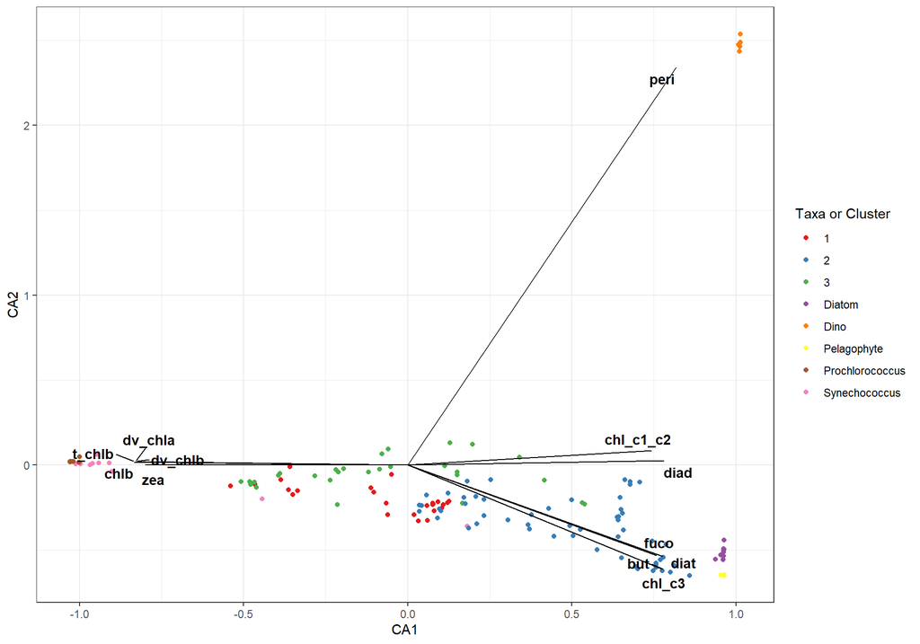

Figure: CA porjection of Monospecific lab HPLC data, with insitu HPLC data as supplementary observation

```r
library(ggrepel)
coord_df <- bind_rows(PCs, cPCs)

pig_and_name <- bind_cols(pig_and_name, coord_df)

ggplot(pig_and_name)+
  geom_point(aes(x = PC1, y = PC2, colour = common_name))+
  geom_segment(aes(x = 0, y = 0, xend =PC1 * 0.8, yend = PC2 * 0.8), data = vPCs)+
  geom_text_repel(aes(x = PC1 * 0.8, y = PC2 * 0.8, label=rownames(vPCs), fontface = 2), data = vPCs)+
  scale_color_brewer(palette = "Set1", name = "Taxa or Cluster")+
  xlab("CA1")+
  ylab("CA2")+
  theme_bw()
```

We notice that the different cultures are well distinguished into three different poles. The Proch and Syn are far on the left of CA1, with typical picophytoplankton pigment (Chlb, zea and Dv-Chla), on the other side of this CA1 we find Diatoms and Pelagophyte with high concentration of fuco, but and chlc3. finally, dinoflagellates are far up on the CA2, due to their unique composition with peridinin.  
The *In-Situ* data are distributed all along the CA1, due to a lack of peridinin in the dataset. All the samples are closer to the center than lab samples because communities are mixed. The CA1 distinguished well the 2nd cluster from the 1st and 3rd.  
We can notice a big drawback from the lab dataset, the lack of 19’-HF in the samples, which represent a significant part of the pigment seasonal and vertical variability at Boussole.  
From there, we can hypothesize that if the 3X1M is pigment sensitiv, it will predict the 2nd cluster much better than the 2 other.  
We can take a look at the same projection without the Dinoflagellates, that may be consider as outliers in the dataset.

```r
library(FactoMineR)
ca_nodino <- filter(pig_ca, common_name != "Dino")

pig_tot_nodino <- bind_rows(ca_nodino, pig_insitu)
index_nodino <- which(pig_tot_nodino$common_name %in%  unique(data_ca$group))

afc_nodino <- CA(select(pig_tot_nodino, -common_name, -f440_f470, -f532_f470), row.sup = index_nodino, graph = FALSE)

pig_and_name_nodino <- result_tot %>% select(common_name, chl_c1_c2:dv_chla, f440_f470, f532_f470) %>%
  filter(common_name != "Dino") %>% right_join(.,pig_tot_nodino)

# extract some parts for plotting
PC1 <- afc_nodino$row$coord[,1]
PC2 <- afc_nodino$row$coord[,2]
labs <- rownames(afc_nodino$row$coord)
PCs <- data.frame(cbind(PC1,PC2))
rownames(PCs) <- labs

# Now get supplementary categorical variables
supPC1 <- afc_nodino$row.sup$coor[,1]
supPC2 <- afc_nodino$row.sup$coor[,2]
clabs <- rownames(afc_nodino$row.sup$coor)
cPCs <- data.frame(cbind(supPC1,supPC2))
rownames(cPCs) <- clabs
colnames(cPCs) <- colnames(PCs)

#
# Now do extract variables
#
vPC1 <- afc_nodino$col$coord[,1]
vPC2 <- afc_nodino$col$coord[,2]
vlabs <- rownames(afc_nodino$col$coord)
vPCs <- data.frame(cbind(vPC1,vPC2))
rownames(vPCs) <- vlabs
colnames(vPCs) <- colnames(PCs)
```

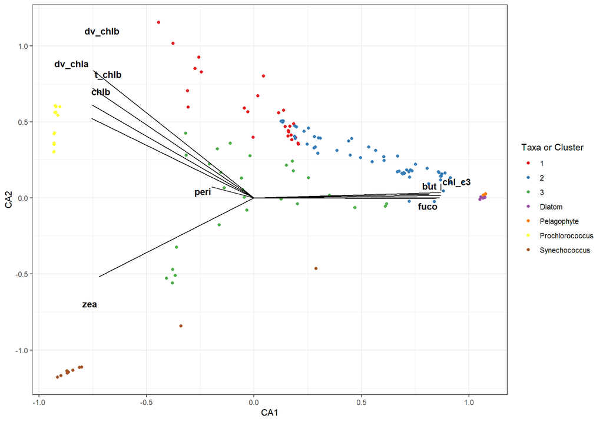

Figure: CA porjection of Monospecific lab HPLC data, with insitu HPLC data as supplementary observation

```r
library(ggrepel)
coord_df <- bind_rows(PCs, cPCs)

pig_and_name_nodino <- bind_cols(pig_and_name_nodino, coord_df)

ggplot(pig_and_name_nodino)+
  geom_point(aes(x = PC1, y = PC2, colour = common_name))+
  geom_segment(aes(x = 0, y = 0, xend =PC1 * 0.8, yend = PC2 * 0.8), data = vPCs)+
  geom_text_repel(aes(x = PC1 * 0.8, y = PC2 , label=rownames(vPCs), fontface = 2), data = vPCs)+
  scale_color_brewer(palette = "Set1", name = "Taxa or Cluster")+
  xlab("CA1")+
  ylab("CA2")+
  theme_bw()
```

```r
train_set <- ca_nodino %>% select(common_name, f440_f470, f532_f470) %>%
  mutate(cluster = case_when(
    common_name == "Prochlorococcus" ~ "cluster_1",
    common_name %in% c("Pelagophyte", "Diatom") ~ "cluster_2",
    common_name == "Synechococcus" ~ "cluster_3")) %>%
  select(- common_name)

test_set <- pig_insitu %>% select(common_name, f440_f470, f532_f470) %>%
  mutate(cluster = case_when(
    common_name == "1" ~ "cluster_1",
    common_name == "2" ~ "cluster_2",
    common_name == "3" ~ "cluster_3")) %>%
  select(- common_name)

path_train_set <- paste(local_path, "Boussole/Output/Data/Compiled/train_cluster_lab.csv", sep ="/")
path_test_set <- paste(local_path, "Boussole/Output/Data/Compiled/test_cluster_insitu.csv", sep ="/")

write_csv(train_set, path_train_set)
write_csv(test_set, path_test_set)
```